# SantoshAgastyaraju_SVAP_Asmt_R2

This case study is on the Farmers Queries in Kisan Call Centre (KCC) from Kurnool district of Andhra Pradesh. The data is downloaded from site in json file format.

# Step-1: Frame the Problem: Identify the key question are you trying to answer

1. Predict the number of calls KCC will receive in 2017 on daily basis

# Step-2: Acquire the Data: Get the dataset to answer the question.

Acquire the data from the json files for each month and then load into data frame.

```r
library(jsonlite)
  filenames <- list.files("F:\\GLIMS-PGPBDA\\Assignments\\SVAP-Assignment\\Assignment-2\\", pattern="*.json", full.names=TRUE)
  jsondata = data.frame()
  for (filename in filenames) {
    print(paste("Processing and Loading the File",filename))
   jsondata = rbind(jsondata,(fromJSON(filename))$data)
  }
```

```
## [1] "Processing and Loading the File F:\\GLIMS-PGPBDA\\Assignments\\SVAP-Assignment\\Assignment-2\\0116.json"
```

```
## [1] "Processing and Loading the File F:\\GLIMS-PGPBDA\\Assignments\\SVAP-Assignment\\Assignment-2\\0216.json"
## [1] "Processing and Loading the File F:\\GLIMS-PGPBDA\\Assignments\\SVAP-Assignment\\Assignment-2\\0316.json"
## [1] "Processing and Loading the File F:\\GLIMS-PGPBDA\\Assignments\\SVAP-Assignment\\Assignment-2\\0416.json"
## [1] "Processing and Loading the File F:\\GLIMS-PGPBDA\\Assignments\\SVAP-Assignment\\Assignment-2\\0516.json"
## [1] "Processing and Loading the File F:\\GLIMS-PGPBDA\\Assignments\\SVAP-Assignment\\Assignment-2\\0716.json"
## [1] "Processing and Loading the File F:\\GLIMS-PGPBDA\\Assignments\\SVAP-Assignment\\Assignment-2\\0816.json"
## [1] "Processing and Loading the File F:\\GLIMS-PGPBDA\\Assignments\\SVAP-Assignment\\Assignment-2\\0916.json"
## [1] "Processing and Loading the File F:\\GLIMS-PGPBDA\\Assignments\\SVAP-Assignment\\Assignment-2\\1016.json"
## [1] "Processing and Loading the File F:\\GLIMS-PGPBDA\\Assignments\\SVAP-Assignment\\Assignment-2\\1116.json"
## [1] "Processing and Loading the File F:\\GLIMS-PGPBDA\\Assignments\\SVAP-Assignment\\Assignment-2\\1216.json"
```

# Step-3: Refine the Data: Do the basic refinement to clean up the dataset.

Remove the leading and trailing spaces in each column in the data frame.

```r
jsondata$Season = gsub("^\\s+|\\s+$", "", jsondata$Season)
jsondata$Sector = gsub("^\\s+|\\s+$", "", jsondata$Sector)
jsondata$Category = gsub("^\\s+|\\s+$", "", jsondata$Category)
jsondata$Crop = gsub("^\\s+|\\s+$", "", jsondata$Crop)
jsondata$QueryType = gsub("^\\s+|\\s+$", "", jsondata$QueryType)
jsondata$QueryText = gsub("^\\s+|\\s+$", "", jsondata$QueryText)
jsondata$KCCAns = gsub("^\\s+|\\s+$", "", jsondata$KCCAns)
jsondata$StateName = gsub("^\\s+|\\s+$", "", jsondata$StateName)
jsondata$DistrictName = gsub("^\\s+|\\s+$", "", jsondata$DistrictName)
jsondata$BlockName = gsub("^\\s+|\\s+$", "", jsondata$BlockName)
jsondata$SubmitDate = gsub("^\\s+|\\s+$", "", jsondata$SubmitDate)
```

# Step-4: Transform the Data: Do the transformation needed for the dataset.

Do the following transformations in the data. 1. Convert the Submit Date to the Date class 2. Find and replace the special characters like ‘’ , ‘’ in the data 3. The data in the KCCAns column is in both upper and lower case. Convert everything to upper case. 4. The Crop alias name is mentioned in the Crop column. Create a seperate column and move the alaias name into it. 5. Split the Submit date into YY , MM , DD columns.

```r
library(dplyr)
library(tidyr)
jsondata$SubmitDate = as.Date(jsondata$SubmitDate,format = '%m/%d/%Y')
jsondata$QueryType = gsub("\\t", "", jsondata$QueryType)
jsondata$KCCAns = gsub("\\t|\\r", "", jsondata$KCCAns)
jsondata$KCCAns = toupper(jsondata$KCCAns)
jsondata= jsondata %>% mutate(tempCrop = Crop) %>%
      separate(tempCrop, c("ActName_Crop", "AltName_Crop"), sep = "\\(")
jsondata= jsondata %>% mutate(tempDate = as.character(jsondata$SubmitDate) ) %>%
      separate(tempDate, c("Year","Month","Date"), sep = "-")

jsondata$ActName_Crop = gsub("^\\s+|\\s+$", "", jsondata$ActName_Crop)
jsondata$AltName_Crop = gsub(")", "", jsondata$AltName_Crop)

jsondata_QueryType_GroupFreq = data.frame('','')
jsondata_QueryType_GroupFreq = data.frame(table(jsondata$QueryType))
colnames(jsondata_QueryType_GroupFreq) = c('QueryType','QueryTypeCount')

jsondata_Season_GroupFreq = data.frame('','')
jsondata_Season_GroupFreq = data.frame(table(jsondata$Season))
colnames(jsondata_Season_GroupFreq) = c('Season','SeasonCount')

jsondata_Sector_GroupFreq = data.frame('','')
jsondata_Sector_GroupFreq = data.frame(table(jsondata$Sector))
colnames(jsondata_Sector_GroupFreq) = c('Sector','SectorCount')

jsondata_BlockName_GroupFreq = data.frame('','')
jsondata_BlockName_GroupFreq = data.frame(table(jsondata$BlockName))
colnames(jsondata_BlockName_GroupFreq) = c('BlockName','BlockNameCount')

jsondata_SubmitMonth_GroupFreq = data.frame('','')
jsondata_SubmitMonth_GroupFreq = data.frame(table(paste(jsondata$Month,"-",jsondata$Year)))
str(jsondata_SubmitMonth_GroupFreq)
```

```
## 'data.frame':    11 obs. of  2 variables:
##  $ Var1: Factor w/ 11 levels "01 - 2016","02 - 2016",..: 1 2 3 4 5 6 7 8 9 10 ...
##  $ Freq: int  629 453 241 194 138 291 427 407 461 280 ...
```

```r
colnames(jsondata_SubmitMonth_GroupFreq) = c('SubmitMonth','SubmitMonthCount')

jsondata_SubmitDate_GroupFreq = data.frame('','')
jsondata_SubmitDate_GroupFreq = data.frame(table(jsondata$SubmitDate))
colnames(jsondata_SubmitDate_GroupFreq) = c('SubmitDate','SubmitDateCount')

jsondata_BlockName_GroupFreq = data.frame('','')
jsondata_BlockName_GroupFreq = data.frame(table(jsondata$BlockName))
colnames(jsondata_BlockName_GroupFreq) = c('BlockName','BlockNameCount')
```

# Step-5: Explore the Data: Create the 3 - 4 individual visualisation that explore the dataset.

Exploring the data by creating the visualisations

1. Bar Chart by grouping based on the QueryType
2. Point Plot by grouping based on the BlockName
3. Bar Chart by grouping based on the Sector
4. Pie Chart by grouping based on Season
5. Bar Chart by grouping based on the Month in which the request is submitted.

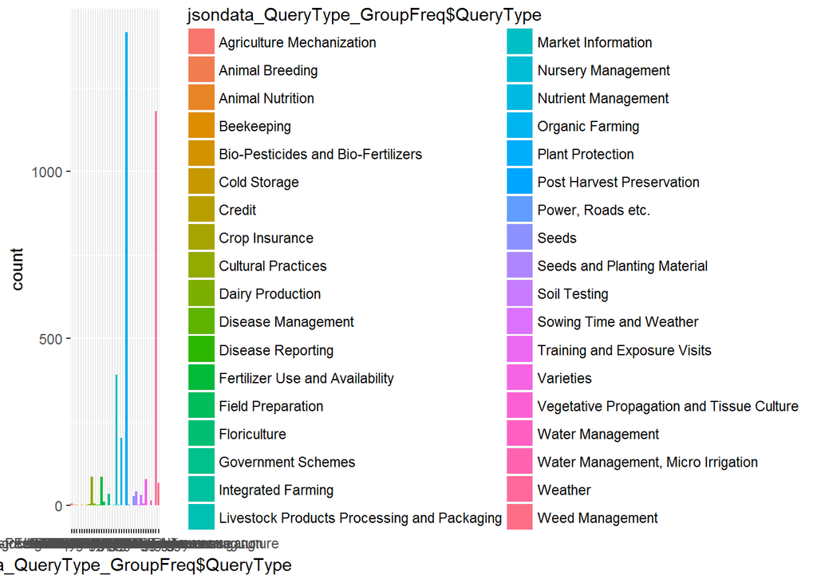

```r
library(ggplot2)
library(plotly)
ggplot(jsondata_QueryType_GroupFreq) + aes(jsondata_QueryType_GroupFreq$QueryType,weight = jsondata_QueryType_GroupFreq$QueryTypeCount,fill=jsondata_QueryType_GroupFreq$QueryType) + geom_bar()
```

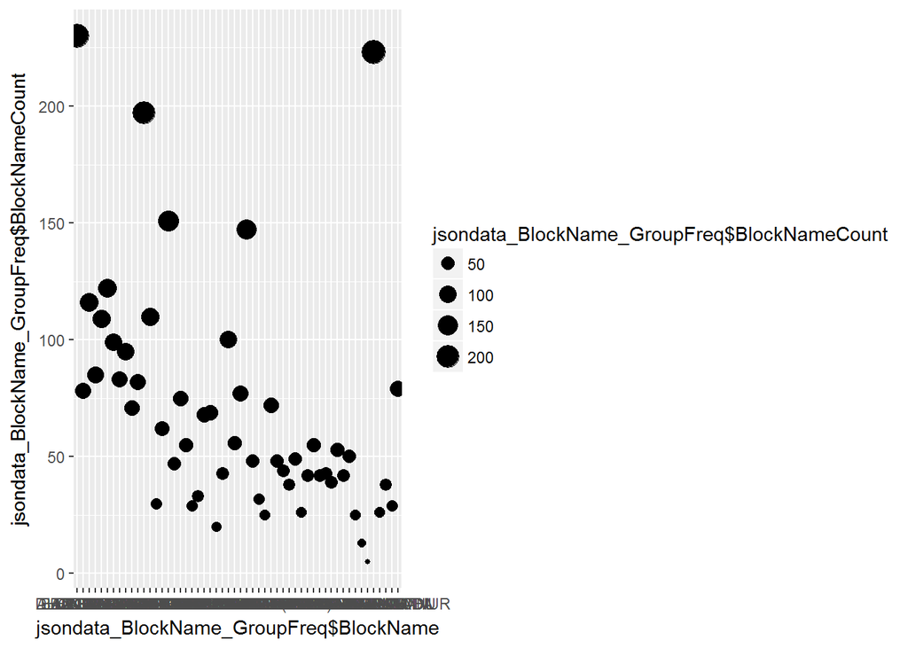

```r
ggplot(jsondata_BlockName_GroupFreq) + aes(jsondata_BlockName_GroupFreq$BlockName,jsondata_BlockName_GroupFreq$BlockNameCount) +  geom_point(aes(size = jsondata_BlockName_GroupFreq$BlockNameCount))
```

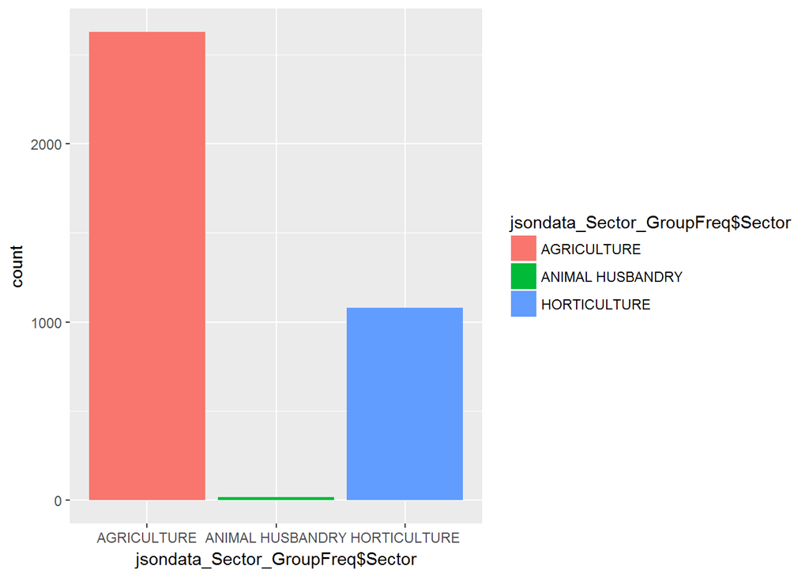

```r
ggplot(jsondata_Sector_GroupFreq) +
  aes(jsondata_Sector_GroupFreq$Sector,weight = jsondata_Sector_GroupFreq$SectorCount,fill=jsondata_Sector_GroupFreq$Sector)  + geom_bar()
```

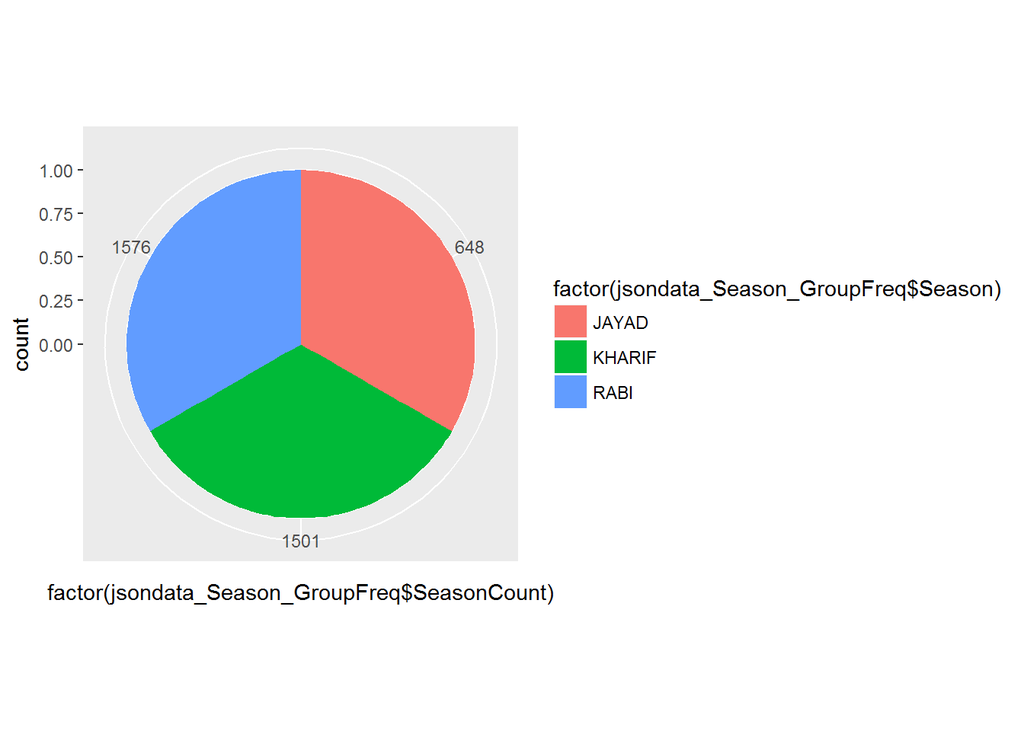

```r
ggplot(jsondata_Season_GroupFreq, aes(x = factor(jsondata_Season_GroupFreq$SeasonCount), fill = factor(jsondata_Season_GroupFreq$Season))) +
 geom_bar(width = 1) + coord_polar(theta = "x")
```

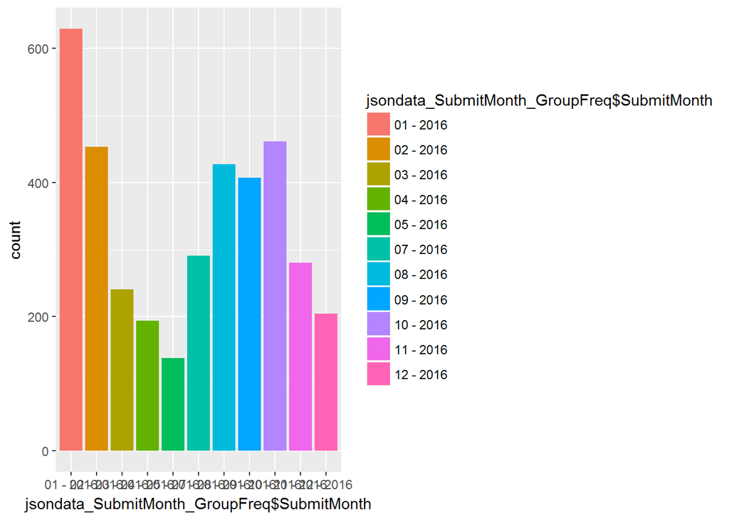

```r
ggplot(jsondata_SubmitMonth_GroupFreq) + aes(jsondata_SubmitMonth_GroupFreq$SubmitMonth,weight = jsondata_SubmitMonth_GroupFreq$SubmitMonthCount,fill=jsondata_SubmitMonth_GroupFreq$SubmitMonth) + geom_bar()
```

# Step-6: Model the Data: Do the basic modelling (as needed) to answer the question

Predict the number of calls KCC will receive in 2017 on daily basis for next 1 year

```r
library("rstan")
library("dplyr")
library("prophet")
```

```
## geom_path: Each group consists of only one observation. Do you need to
## adjust the group aesthetic?
```

[figure not shown]

```r
ggplot(jsondata_SubmitDate_GroupFreq) + aes(jsondata_SubmitDate_GroupFreq$SubmitDate,jsondata_SubmitDate_GroupFreq$SubmitDateCount) + geom_line()
```

```r
colnames(jsondata_SubmitDate_GroupFreq) <- c('ds', 'y')
prophetObject <- prophet(jsondata_SubmitDate_GroupFreq)
```

```
## Initial log joint probability = -11.0293
## Optimization terminated normally:
##   Convergence detected: relative gradient magnitude is below tolerance
```

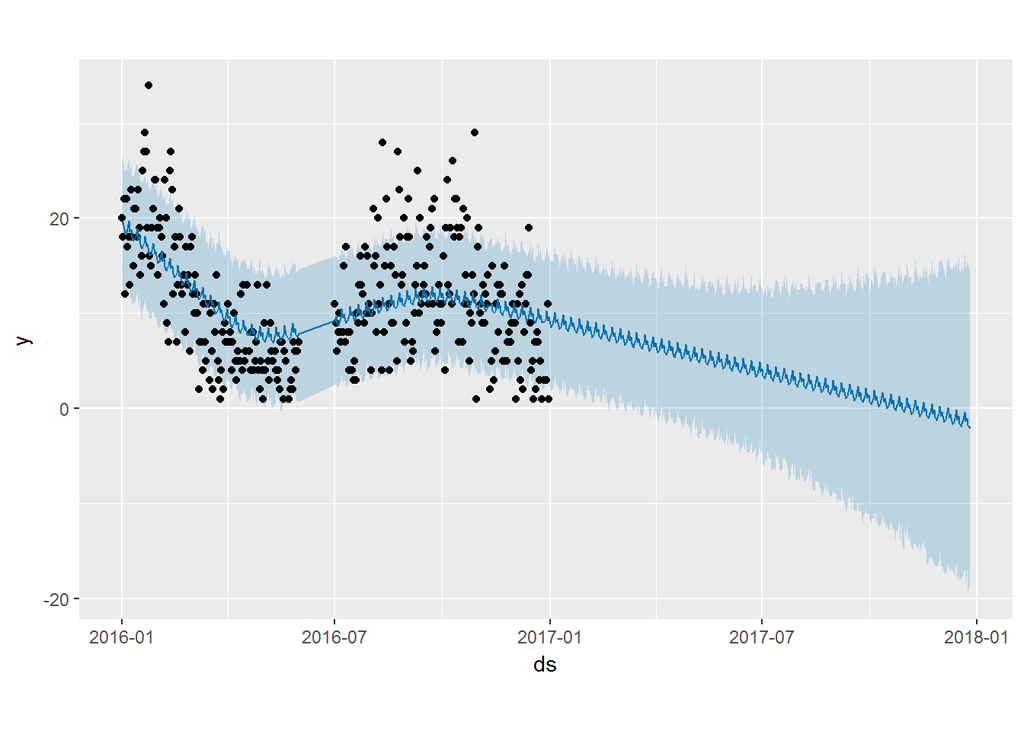

```r
futuredataFrame <- make_future_dataframe(prophetObject, periods = 360, freq = 'd', include_history = TRUE )
forecastData <- predict(prophetObject, futuredataFrame)
plot(prophetObject, forecastData)
```

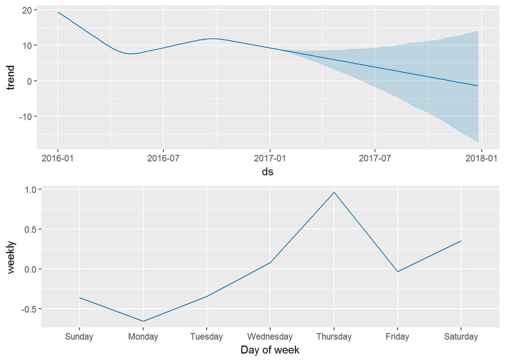

```r
prophet_plot_components(prophetObject, forecastData)
```

# Step-7: Communicate the insight: Create final visualisations to share the insight.

```r
library(ggmap)
BlockGeoLoc = geocode(as.character(jsondata_BlockName_GroupFreq$BlockName))
```

[output not shown]

[output not shown]

[output not shown]

[output not shown]

[output not shown]

[output not shown]

[output not shown]

[output not shown]

[output not shown]

[output not shown]

[output not shown]

[output not shown]

[output not shown]

[output not shown]

[output not shown]

[output not shown]

[output not shown]

[output not shown]

[output not shown]

[output not shown]

[output not shown]

[output not shown]

[output not shown]

[output not shown]

[output not shown]

[output not shown]

[output not shown]

[output not shown]

[output not shown]

[output not shown]

[output not shown]

[output not shown]

[output not shown]

[output not shown]

[output not shown]

[output not shown]

[output not shown]

[output not shown]

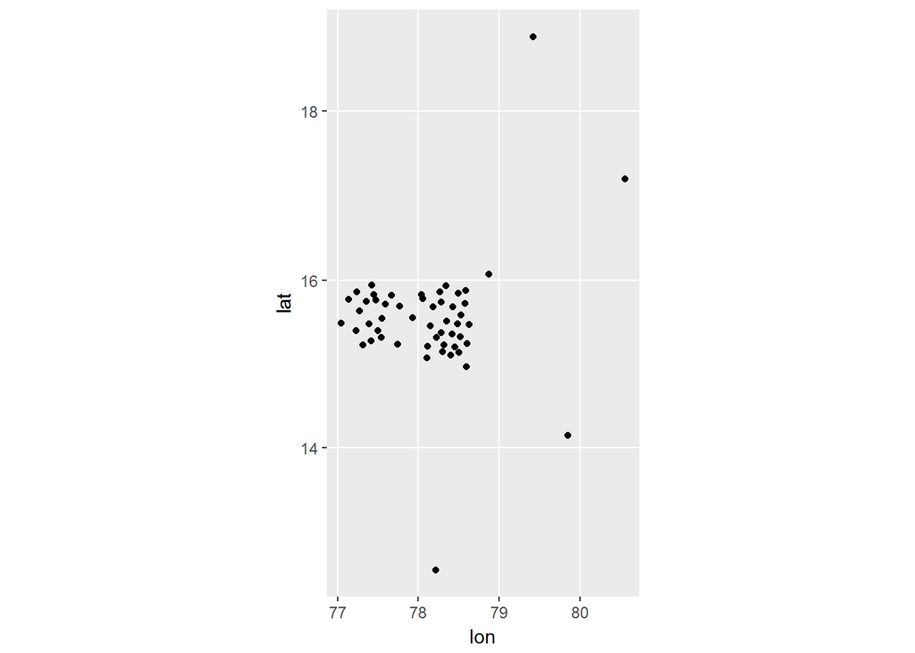

```r
dfGeoLoc = bind_cols(data.frame(jsondata_BlockName_GroupFreq$BlockName),BlockGeoLoc, jsondata_BlockName_GroupFreq)
ggplot(dfGeoLoc) + aes(lon, lat) + geom_point() + coord_map()
```

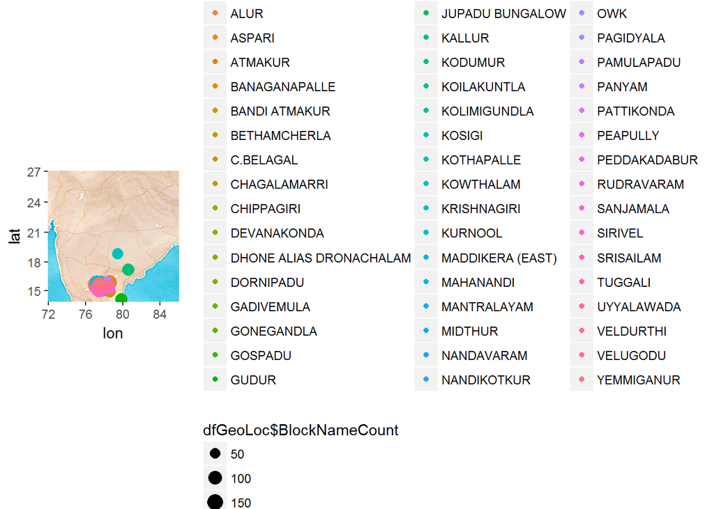

```r
IndiaMap <- get_map("India", maptype = "watercolor", source = "stamen", zoom = 6)
ggmap(IndiaMap) + geom_point(data = dfGeoLoc,aes(lon,lat,size = dfGeoLoc$BlockNameCount,color = dfGeoLoc$BlockName))
```